# Combination of results from different analysis for metabolic changes in IBD patients

Jan Taubenheim

2022-04-21

# 1 Libraries

```r
require(data.table)
require(ggplot2)
require(ComplexUpset)
require(clusterProfiler)
require(psych)
require(lme4)
require(lmerTest)
require(psych)
```

# 2 Introduction

The general idea is to find changes in the metabolic network of IBD patients which are associated with a change the disease activity scores. I analysed data sets for the reaction activity scores, the presence/absence of reactions after context specific model reconstruction and FVA analysis using a reaction based LMM approach. This results in sets of reactions, which are associated with the disease activity. I used these reactions as filtering step to perform a search for reactions which are associated with a change in the remission to different treatments of the IBD-Patients.

# 3 Results

## 3.1 Reaction association

First lets look at the reactions which are shared between the different analysis.

```r
sigs.rxnExpr <- fread("./Statistics/results/rxnExpr_GLMMsRemissionAll_coefs.csv")
sigs.rxnExpr <- sigs.rxnExpr[padj < 0.05,]
sigs.PA <- fread("./Statistics/results/PA_GLMMsRemissionAll_coefs.csv")
sigs.PA <- sigs.PA[padj < 0.05,]
sigs.FVA <- fread("./Statistics/results/FVA_GLMMsRemissionAll_coefs.csv")
sigs.FVA <- sigs.FVA[padj < 0.05,]

sigs <- list(rxnExpr = sigs.rxnExpr,
             PA = sigs.PA,
             FVA = sigs.FVA)

# annotations
subsystems <- fread("./Statistics/dat/subsystems.csv")
rxnAnno <- fread("../../resources/recon-store-reactions-1.tsv")
```

Here is an upset plot for the reactions.

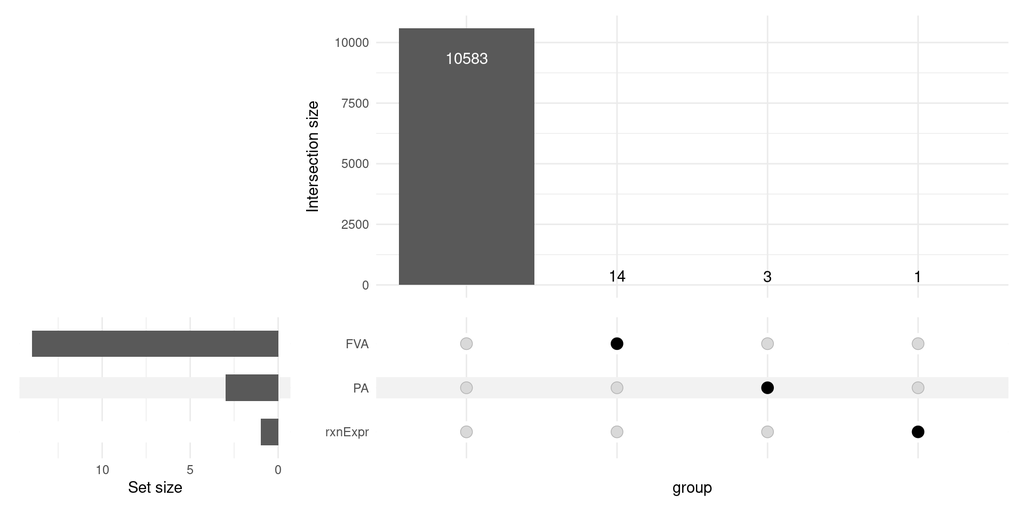

```r
rxns <- unique(c(subsystems[,reaction], unlist(sapply(sigs,function(x) x[,rxn]))))

vennMat <- matrix(0, nrow = length(rxns), ncol = length(sigs), dimnames = list(rxns, names(sigs)))
for(set.nm in names(sigs)){
    set <- sigs[[set.nm]]
    vennMat[set[,rxn],set.nm] <- 1
}

upset(as.data.frame(vennMat), intersect = colnames(vennMat))
```

There are 0 reactions which are associated in all analysis with treatment remission changes. Here is the complete list:

|  | abbreviation | description | formula | subsystem | ecnumber | keggId | keggorthology | cog | seed | metanetx |
| --- | --- | --- | --- | --- | --- | --- | --- | --- | --- | --- |

From all the reactions we can make another hypergeometric enrichment - which would be an overall assessment of the analysis performed.

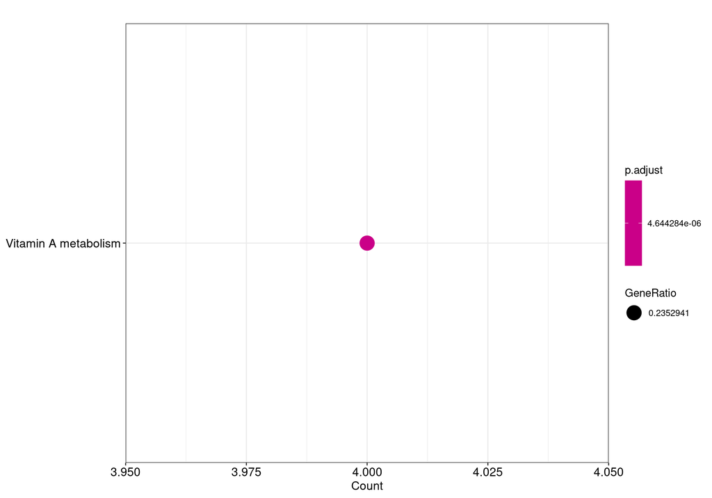

```r
hgt <- enricher(unique(unlist(sapply(sigs, function(x) x[,rxn]))), TERM2GENE = subsystems)
dotplot(hgt, x = "Count", showCategory = nrow(data.frame(hgt)))
```

## 3.2 Subsystem association

Similar we can make a summary of the subsystems by comparing the different subsystems which have been enriched in the different analysis and with GSEA and HGT.

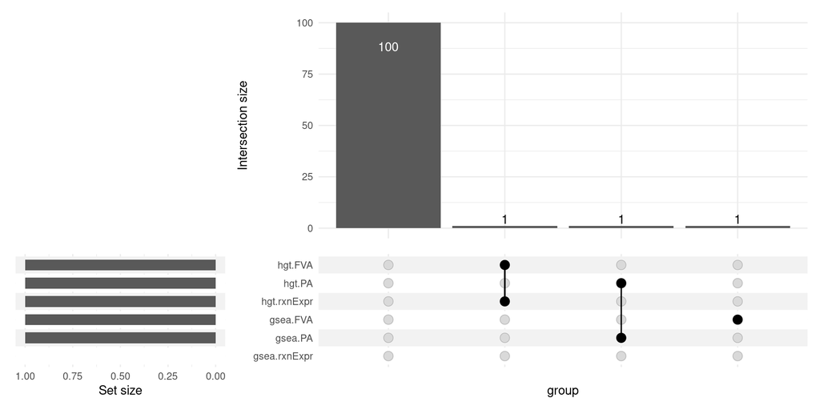

```r
#gsea.rxnExpr <- readRDS("Statistics/results/rxnExpr_GSEASubsystems_Remission.RDS")
gsea.PA <- readRDS("Statistics/results/PA_GSEASubsystems_Remission.RDS")
gsea.FVA <- readRDS("Statistics/results/FVA_GSEASubsystems_Remission.RDS")

vennMat.subsys <- matrix(0, ncol = 2*length(sigs), nrow = length(unique(subsystems[,subsystem])),
                         dimnames = list(unique(subsystems[,subsystem]),
                                         paste0(sort(rep(c("hgt.","gsea."), length(sigs))), rep(names(sigs),2)))
                         )
for(n in names(sigs)){
    hgt <- enricher(sigs[[n]][,rxn],TERM2GENE = subsystems)
    vennMat.subsys[data.frame(hgt)[,"ID"], paste0("hgt.",n)] <- 1
    gsea <-paste0("gsea.",n)
    if(exists(gsea)){
        gsea <- get(gsea)
        vennMat.subsys[data.frame(gsea)[,"ID"], paste0("gsea.",n)] <- 1
    }
}

upset(as.data.frame(vennMat.subsys), intersect = colnames(vennMat.subsys))
```

```r
dt.vennMat.subsys <- data.table(vennMat.subsys, total = rowSums(vennMat.subsys), keep.rownames = TRUE)

DT::datatable(dt.vennMat.subsys[total > 1,])
```

|  | rn | gsea.rxnExpr | gsea.PA | gsea.FVA | hgt.rxnExpr | hgt.PA | hgt.FVA | total |
| --- | --- | --- | --- | --- | --- | --- | --- | --- |
| 1 | Cholesterol metabolism | 0 | 1 | 0 | 0 | 1 | 0 | 2 |
| 2 | Vitamin A metabolism | 0 | 0 | 0 | 1 | 0 | 1 | 2 |

There is(are) exactly 0 subsystem(s) which is(are) found across all analysis. That is:

```r
tbl.subsys <- rxnAnno[subsystem %in% rownames(vennMat.subsys)[rowSums(vennMat.subsys) == ncol(vennMat.subsys)],]
DT::datatable(tbl.subsys)
```

|  | abbreviation | description | formula | subsystem | ecnumber | keggId | keggorthology | cog | seed | metanetx |
| --- | --- | --- | --- | --- | --- | --- | --- | --- | --- | --- |

## 3.3 Diversity measures

An interesting finding was, that generally there were more reactions which, if present/active, there was a reduction in disease activity. This can be either an effect that certain reactions are really blocked/reduced in activity if HB/Mayo scores are high or it is a result of a reduced metabolic diversity in higher inflammation states. To test that one can correlate the HB/Mayo score with the diversity measures of the different analysis.

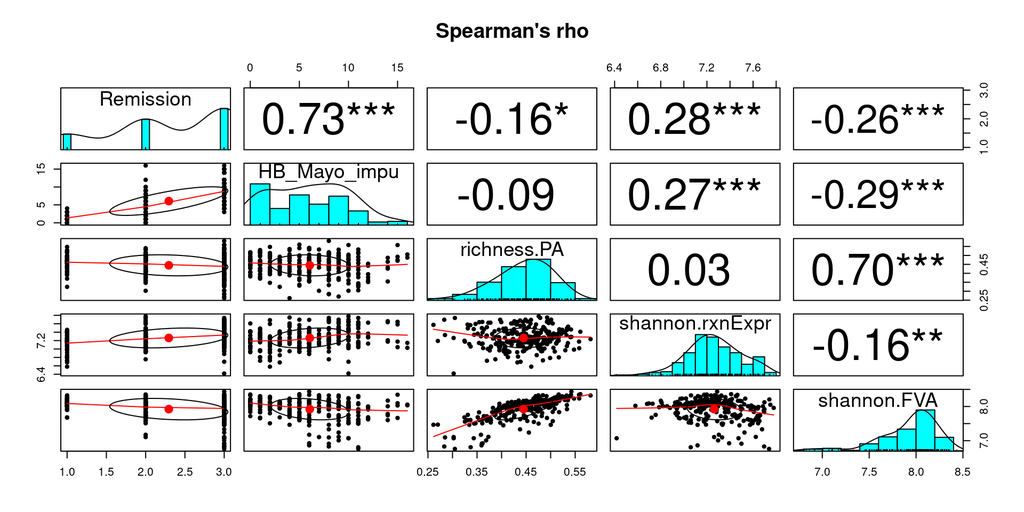

```r
diversity <- fread("Statistics/results/diversityMeasures.csv")
diversity[, Remission := factor(Remission, levels = c("C","R","NR"))]
pairs.panels(diversity[,.(Remission,HB_Mayo_impu,richness.PA, shannon.rxnExpr, shannon.FVA)],
           method = "spearman",
           stars = TRUE,
           main = "Spearman's rho")
```

So there are slight correlation, which poses the question, whether this signal remains, if tested in a linear mixed model to correct for PatientID independence.

```r
mod.richness.PA <- glmer(data = diversity,
                        Remission ~ richness.PA + (1|PatientID),
                        family = binomial)
mod.shannon.rxnExpr <- glmer(data = diversity,
                        Remission ~ shannon.rxnExpr + (1|PatientID),
                        family = binomial)
mod.shannon.FVA <- glmer(data = diversity,
                        Remission ~ shannon.FVA + (1|PatientID),
                        family = binomial)


stats <- data.table(rbind(
                          car::Anova(mod.richness.PA),
                          car::Anova(mod.shannon.rxnExpr),
                          car::Anova(mod.shannon.FVA)),
                    keep.rownames = TRUE)#[rn != "(Intercept)",]
stats[,padj := p.adjust(`Pr(>Chisq)`, method = "BH")]
DT::datatable(stats)
```

|  | rn | Chisq | Df | Pr(>Chisq) | padj |
| --- | --- | --- | --- | --- | --- |
| 1 | richness.PA | 0.0198840544929798 | 1 | 0.887861385846521 | 0.887861385846521 |
| 2 | shannon.rxnExpr | 0.267503716010219 | 1 | 0.605011237470862 | 0.887861385846521 |
| 3 | shannon.FVA | 0.33123168557878 | 1 | 0.564934725487822 | 0.887861385846521 |

# 4 Combining information from all data

## 4.1 PCA for clustering

Another idea is to use the different significant reactions and use the data to make a ordination to get a feeling how well we can separate the different samples form each other by the treatment remission.

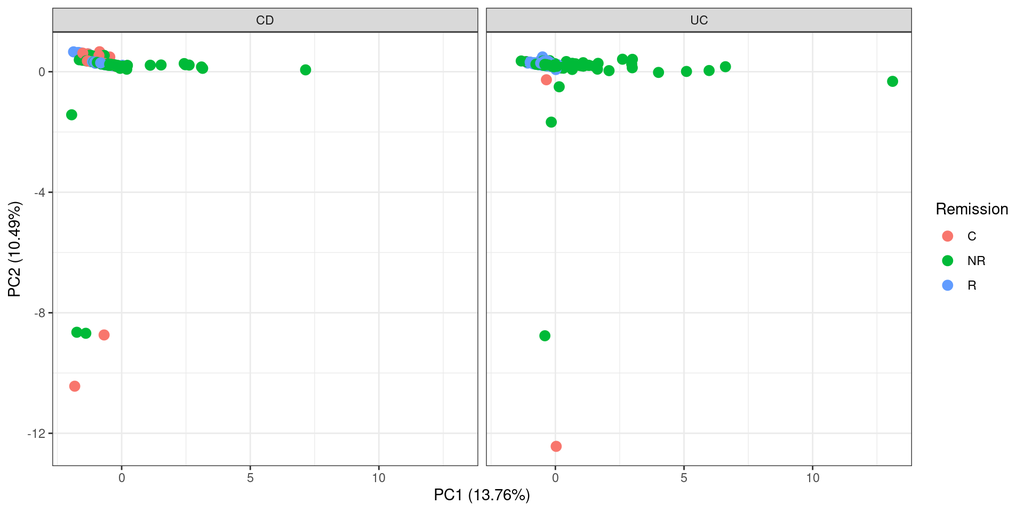

```r
# used for meta data

diversity <- fread("Statistics/results/diversityMeasures.csv")

rxnExpr <- read.csv("../results/RxnExpression/rxnExpr.GL10-L50-GU90.colormore3D.csv", row.names=1)
rxnExpr <- rxnExpr[sigs.rxnExpr[,rxn],]
PA <- read.csv("../results/ModelAnalysis/rxnIdMat.GL10-L50-GU90.MatjesAbsorption.colormore3D.csv", row.names=1)
PA <- PA[sigs.PA[,rxn],]
# make PA to integer
PA2 <- PA
PA2[,] <- 0
PA2[PA == "True"] <- 1
PA <- PA2
FVA.range <- read.csv("../results/FVA/rangeFVA.GL10-L50-GU90.MatjesAbsorption.colormore3D.csv", row.names=1)
FVA.range <- FVA.range[sigs.FVA[coef == "range",rxn],]
FVA.center <- read.csv("../results/FVA/centerFVA.GL10-L50-GU90.MatjesAbsorption.colormore3D.csv", row.names=1)
FVA.center <- FVA.center[sigs.FVA[coef == "center",rxn],]


# transform the PA data to jaccard distances, otherwise it is less meaningful
PA.dist <- as.matrix(dist(t(PA), method = "binary"))
mat.all <- t(rbind(PA,rxnExpr, FVA.center, FVA.range))

pca <- prcomp(mat.all, scale = TRUE, center = TRUE)
pca.x <- merge(data.table(pca[["x"]], keep.rownames = TRUE), diversity, by.x = "rn", by.y = "SeqID")
pca.var <- pca[["sdev"]]^2/sum(pca[["sdev"]]^2)*100

pca.plot <- ggplot(pca.x, aes(x=PC1,y=PC2)) +
   # scale_color_gradient(low = "blue", high ="red") +
    #geom_point(aes(color = log10(Time_seq+1), shape =Remission),size = 3) +
    geom_point(aes(color = Remission),size = 3) +
    theme_bw() +
    facet_grid(~Diagnosis) +
    labs(y = paste0("PC2 (", round(pca.var[2],2),"%)"),
         x = paste0("PC1 (", round(pca.var[1],2),"%)"),
         shape = "Time in days")
pca.plot
```

```r
## only the rxns common in all
#rxns <- rownames(vennMat)[rowSums(vennMat) == ncol(vennMat)]
#PA.common.dist <- as.matrix(dist(t(PA[rxns,])))
#FVA.common.range  <- FVA.range[rxns,]
#FVA.common.center <- FVA.center[rxns,]
#FVA.common <- rbind(FVA.common.range, FVA.common.center)
#FVA.common <- FVA.common[apply(FVA.common, 1, function(x) !all(is.na(x))),]
#rxnExpr.common <- rxnExpr[rxns,]
#mat.common.all <- t(rbind(rxnExpr.common, PA.common.dist, FVA.common))
#pca.common <- prcomp(mat.common.all, scale = TRUE, center = TRUE)

#pca.common.x <- merge(data.table(pca.common[["x"]], keep.rownames = TRUE), diversity, by.x = "rn", by.y = "SeqID")
#pca.common.var <- pca.common[["sdev"]]^2/sum(pca.common[["sdev"]]^2)*100
#
#pca.common.plot <- ggplot(pca.common.x, aes(x=PC1,y=PC2)) +
#    geom_point(aes(color = Remission),size = 3, alpha = 0.3) +
#    theme_bw() +
#    facet_grid(~Diagnosis) +
#    labs(y = paste0("PC2 (", round(pca.common.var[2],2),"%)"),
#         x = paste0("PC1 (", round(pca.common.var[1],2),"%)"))
#pca.common.plot
```

# 5 Finding correlated exchange reactions

In order to detect those metabolites which probably show an influence on the metabolic network and the significant reactions I correlated the values of the significant reactions for presence/absence and FVA center and range to the values of the values to the exchange reactions. I took the mean of the correlation coefficient for each rxn/Ex_rxn pair and kept the top 1% values for each rxn. I further calculated the mean of all coefficients for the significant rxns in the LMMs and multiplied the two values. This left me with a value which describes the strength of the correlation for a rxns to the exchange of a metabolite and the strength of the rxn change to the Remission score. It thus gives us values to rank the different metabolites to the change in Remission.

NOTE: I reversed the correlation coefficients and the LMM coefficients for the results of the FVA center analysis in order to comply with a more readily interpretable result. This means more uptake of the metabolite will increase the be positively associated with an increase in the center of the rxn in question.

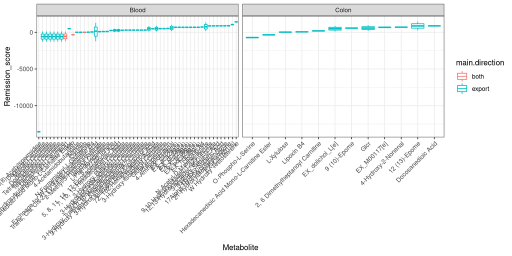

```r
topcor <- fread("Statistics/results/ExCorrelation_summary.csv")



# filter the exchange reactions, which show a significant effect which is different from 0
topcor.ttests <- topcor[!is.na(Remission_score), .(p.value = tryCatch({
                                                    t.test(Remission_score)[["p.value"]]
                                                }, error = function(e){1.0}),
                                                Remission_score_mean = mean(Remission_score),
                                                Remission_score_sum = sum(Remission_score),
                                                NoRxns = .N), by = .(rn,main.direction)]

topcor.ttests[,padj := p.adjust(p.value, method = "BH")]
topcor.ttests[,rxn_base := gsub("\\[.\\]","",rn)]
rxnAnno[,rxn_base := gsub("\\[.\\]","",abbreviation)]
topcor.ttests <- merge(topcor.ttests, rxnAnno[,.(rxn_base, description)], by = "rxn_base")
topcor.ttests[,description := gsub(".* of","", description)]
topcor.ttests[,Metabolite := factor(description, levels = unique(description[order(Remission_score_sum)]))]
topcor.ttests[, compartment := "Colon"]
topcor.ttests[grep(".*\\[e\\]",rn), compartment := "Blood"]

setkey(topcor.ttests, "rn")

# get those which have the largest deviation from 0 (based on the ttest p.value)
top100 <- topcor.ttests[, rn]#[1:20]

plt.dat <- topcor[rn %in% top100,]
plt.dat <- merge(plt.dat, rxnAnno, by.x = "rn", by.y = "abbreviation", all.x = TRUE)
plt.dat[,Metabolite := factor(topcor.ttests[rn,Metabolite], levels = unique(topcor.ttests[order(Remission_score_mean),Metabolite]))]
plt.dat[, compartment := "Colon"]
plt.dat[grep(".*\\[e\\]",rn), compartment := "Blood"]

plt.excor <- ggplot(plt.dat, aes(x = Metabolite, y = Remission_score, color = main.direction)) +
    geom_boxplot() +
    theme_bw() +
    theme(axis.text.x = element_text(angle = 45, hjust = 1 , vjust =1))+
    facet_grid(~compartment, scale = "free_x")
plt.excor
```

```r
DT::datatable(topcor.ttests)
```

|  | rxn_base | rn | main.direction | p.value | Remission_score_mean | Remission_score_sum | NoRxns | padj | description | Metabolite | compartment |
| --- | --- | --- | --- | --- | --- | --- | --- | --- | --- | --- | --- |
| 1 | EX_17ahprgnlone | EX_17ahprgnlone[e] | export | 1 | 884.498365935777 | 884.498365935777 | 1 | 1 | 17Alpha-Hydroxypregnenolone | 17Alpha-Hydroxypregnenolone | Blood |
| 2 | EX_2m3hvac | EX_2m3hvac[e] | export | 1 | 86.7128491213813 | 86.7128491213813 | 1 | 1 | 2-Methyl-3-Hydroxy-Valerate | 2-Methyl-3-Hydroxy-Valerate | Blood |
| 3 | EX_3bcrn | EX_3bcrn[e] | export | 1 | 297.293273283043 | 297.293273283043 | 1 | 1 | 3-Hydroxy Butyryl Carnitine | 3-Hydroxy Butyryl Carnitine | Blood |
| 4 | EX_3hadpac | EX_3hadpac[e] | export | 0.423665792339499 | 491.311766973557 | 982.623533947115 | 2 | 1 | 3-Hydroxy-Adipate | 3-Hydroxy-Adipate | Blood |
| 5 | EX_3ivcrn | EX_3ivcrn[e] | export | 1 | 493.032783925353 | 493.032783925353 | 1 | 1 | 3-Hydroxy-Isovaleryl Carnitine | 3-Hydroxy-Isovaleryl Carnitine | Blood |
| 6 | EX_3octdec2crn | EX_3octdec2crn[e] | export | 1 | 298.945036031847 | 298.945036031847 | 1 | 1 | 3-Hydroxyoctadecadienoyl Carnitine | 3-Hydroxyoctadecadienoyl Carnitine | Blood |
| 7 | EX_3octdece1crn | EX_3octdece1crn[e] | export | 1 | 298.945036031847 | 298.945036031847 | 1 | 1 | 3-Hydroxy-Octadecenoyl Carnitine | 3-Hydroxy-Octadecenoyl Carnitine | Blood |
| 8 | EX_3ohsebac | EX_3ohsebac[e] | export | 1 | 876.963892330842 | 876.963892330842 | 1 | 1 | 3-Hydroxy-Sebacic Acid | 3-Hydroxy-Sebacic Acid | Blood |
| 9 | EX_3ohsubac | EX_3ohsubac[e] | export | 1 | 876.963892330842 | 876.963892330842 | 1 | 1 | 3-Hydoxy-Suberic Acid | 3-Hydoxy-Suberic Acid | Blood |
| 10 | EX_3tetd7ecoacrn | EX_3tetd7ecoacrn[e] | export | 1 | 298.945036031848 | 298.945036031848 | 1 | 1 | 3-Hydroxy Tetradecenoyl-7-Carnitine | 3-Hydroxy Tetradecenoyl-7-Carnitine | Blood |

[output cut: 55 more lines]

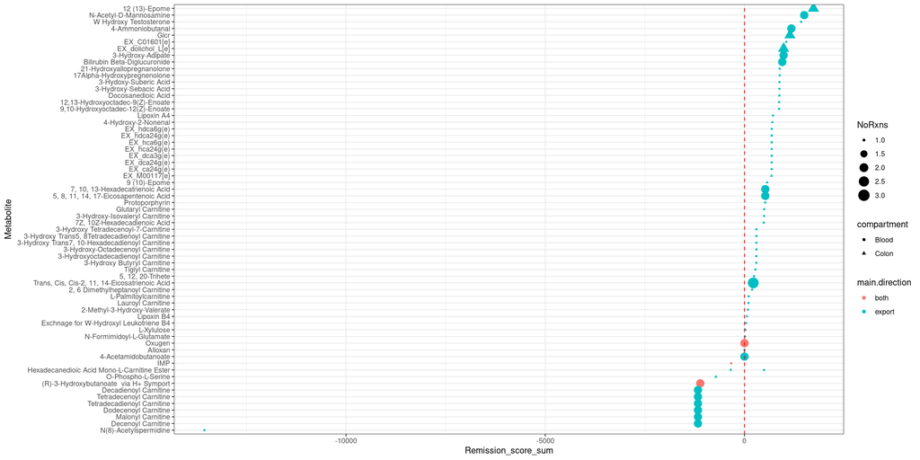

```r
# another way of plotting would be summing the scores by exchange reaction

topcor.sums.plt <- ggplot(topcor.ttests, aes(x = Remission_score_sum, y = Metabolite, size = NoRxns, color = main.direction, shape = compartment)) +
    geom_point() +
    geom_vline(linetype = 2, color = "red", xintercept = 0) +
    theme_bw()
topcor.sums.plt
```

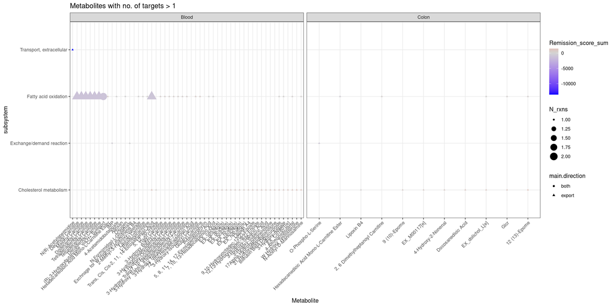

```r
# relating these exchange reactions back to the subsystems
topcor.merge <- merge(topcor, rxnAnno[,.(abbreviation, subsystem)], by.x = "rxn", by.y = "abbreviation")

topcor.subsystems <- topcor.merge[rn %in% topcor.ttests[, rn] & !is.na(Remission_score),
                            .(Remission_score_mean = mean(Remission_score,na.rm =TRUE),
                              Remission_score_sum = sum(Remission_score, na.rm = TRUE),
                              N_rxns = .N),
                            by=.(rn,subsystem, main.direction)]
topcor.subsystems[, compartment := "Colon"]
topcor.subsystems[grep(".*\\[e\\]",rn), compartment := "Blood"]
topcor.subsystems[,Metabolite := topcor.ttests[rn,Metabolite]]



ggplot(topcor.subsystems, aes(x=Metabolite, y = subsystem, size = N_rxns,color = Remission_score_sum)) +
    geom_point(aes(shape = main.direction)) +
    scale_color_gradient2(high = "red",low = "blue",mid = "light grey",midpoint = 0)+
    theme_bw()+
    ggtitle("Metabolites with no. of targets > 1") +
    theme(axis.text.x = element_text(angle = 45, hjust = 1 , vjust =1))+
    facet_grid(~compartment, scale = "free_x")
```